# NDFS Synthesis Manuscript: Chlorophyll analysis

GAM model using daily average flow as continuous predictor

Dave Bosworth

September 27, 2023

# Purpose

Explore and analyze the continuous chlorophyll data to be included in the NDFS synthesis manuscript. We will attempt to fit a generalized additive model (GAM) to the data set to help account for seasonality in the data. This is an extension of the original analysis which used a categorical predictor for flow action period. In this analysis we will replace this categorical predictor with daily average flow as a continuous predictor.

# Global code and functions

```r
# Load packages
library(tidyverse)
library(lubridate)
library(scales)
library(knitr)
library(mgcv)
library(lme4)
library(car)
library(emmeans)
library(gratia)
library(visreg)
library(here)
library(conflicted)

# Declare package conflict preferences
conflicts_prefer(dplyr::filter())
```

# Import Data

```r
# Define file path for processed data
fp_data <- here("manuscript_synthesis/data/processed")

# Import daily average chlorophyll data
df_chla <- readRDS(file.path(fp_data, "chla_wt_daily_avg_2013-2019.rds")) %>% select(-WaterTemp)

# Import daily average flow data
df_flow <- readRDS(file.path(fp_data, "flow_daily_avg_2013-2019.rds"))
```

# Prepare Data

```r
# Create a vector for the factor order of StationCode
sta_order <- c(
  "RCS",
  "RD22",
  "I80",
  "LIS",
  "STTD",
  "LIB",
  "RVB"
)

# We will use LIS flow data as a proxy for STTD and RD22 flow data as a proxy
  # for I-80
df_flow_c <- df_flow %>%
  filter(StationCode %in% c("RD22", "LIS")) %>%
  mutate(StationCode = case_match(StationCode, "RD22" ~ "I80", "LIS" ~ "STTD")) %>%
  bind_rows(df_flow)

# Prepare chlorophyll and flow data for exploration and analysis
df_chla_c1 <- df_chla %>%
  # Remove RYI since its chlorophyll data is so sparse
  filter(StationCode != "RYI") %>%
  # Join flow data to chlorophyll data
  left_join(df_flow_c, by = join_by(StationCode, Date)) %>%
  # Remove all NA flow values
  drop_na(Flow) %>%
  mutate(
    # Scale and log transform chlorophyll values
    Chla_log = log(Chla * 1000),
    # Add Year and DOY variables
    Year = year(Date),
    DOY = yday(Date),
    # Apply factor order to StationCode
    StationCode = factor(StationCode, levels = sta_order),
    # Add a column for Year as a factor for the model
    Year_fct = factor(Year)
  ) %>%
  arrange(StationCode, Date)
```

# Explore sample counts by Station

```r
df_chla_c1 %>%
  summarize(
    min_date = min(Date),
    max_date = max(Date),
    num_samples = n(),
    .by = c(StationCode, Year)
  ) %>%
  arrange(StationCode, Year) %>%
  kable()
```

| StationCode | Year | min_date | max_date | num_samples |
| --- | --- | --- | --- | --- |
| RCS | 2014 | 2014-07-25 | 2014-09-24 | 58 |
| RCS | 2015 | 2015-08-17 | 2015-09-28 | 43 |
| RCS | 2016 | 2016-06-23 | 2016-09-16 | 73 |
| RCS | 2017 | 2017-07-14 | 2017-11-03 | 103 |
| RCS | 2018 | 2018-07-13 | 2018-11-11 | 122 |
| RCS | 2019 | 2019-07-11 | 2019-11-06 | 119 |
| RD22 | 2014 | 2014-09-30 | 2014-11-08 | 40 |
| RD22 | 2015 | 2015-07-24 | 2015-11-10 | 110 |
| RD22 | 2016 | 2016-06-23 | 2016-09-16 | 86 |
| RD22 | 2017 | 2017-07-14 | 2017-11-03 | 113 |
| RD22 | 2018 | 2018-07-13 | 2018-11-11 | 122 |
| RD22 | 2019 | 2019-07-11 | 2019-11-06 | 119 |
| I80 | 2014 | 2014-09-30 | 2014-11-08 | 40 |
| I80 | 2015 | 2015-07-24 | 2015-11-10 | 91 |
| I80 | 2016 | 2016-06-23 | 2016-09-16 | 86 |
| I80 | 2017 | 2017-07-14 | 2017-11-03 | 113 |
| I80 | 2018 | 2018-07-13 | 2018-11-11 | 122 |
| I80 | 2019 | 2019-07-11 | 2019-11-06 | 119 |
| LIS | 2013 | 2013-07-07 | 2013-11-17 | 107 |
| LIS | 2014 | 2014-07-25 | 2014-11-04 | 102 |
| LIS | 2015 | 2015-07-06 | 2015-11-16 | 129 |
| LIS | 2016 | 2016-05-29 | 2016-09-16 | 108 |
| LIS | 2017 | 2017-07-14 | 2017-11-03 | 104 |
| LIS | 2018 | 2018-07-13 | 2018-11-11 | 118 |
| LIS | 2019 | 2019-07-19 | 2019-11-06 | 107 |
| STTD | 2013 | 2013-08-15 | 2013-11-04 | 78 |
| STTD | 2014 | 2014-07-25 | 2014-10-19 | 87 |
| STTD | 2015 | 2015-07-27 | 2015-11-16 | 108 |
| STTD | 2016 | 2016-06-23 | 2016-09-16 | 83 |
| STTD | 2017 | 2017-07-14 | 2017-09-25 | 56 |
| STTD | 2018 | 2018-07-20 | 2018-10-11 | 84 |
| STTD | 2019 | 2019-07-26 | 2019-11-06 | 100 |
| LIB | 2014 | 2014-10-01 | 2014-11-08 | 36 |
| LIB | 2015 | 2015-07-06 | 2015-11-16 | 125 |
| LIB | 2016 | 2016-05-29 | 2016-09-16 | 101 |
| LIB | 2017 | 2017-07-14 | 2017-11-02 | 96 |
| LIB | 2018 | 2018-08-14 | 2018-10-31 | 36 |
| LIB | 2019 | 2019-07-11 | 2019-10-25 | 31 |
| RVB | 2013 | 2013-07-07 | 2013-11-17 | 134 |
| RVB | 2014 | 2014-07-25 | 2014-11-08 | 105 |
| RVB | 2015 | 2015-07-06 | 2015-11-16 | 134 |
| RVB | 2016 | 2016-05-29 | 2016-09-16 | 80 |
| RVB | 2017 | 2017-07-14 | 2017-11-03 | 113 |
| RVB | 2018 | 2018-07-13 | 2018-11-11 | 122 |
| RVB | 2019 | 2019-07-11 | 2019-11-06 | 102 |

Looking at the sample counts and date ranges, we’ll only include years 2015-2019 for the analysis.

```r
df_chla_c2 <- df_chla_c1 %>%
  filter(Year %in% 2015:2019) %>%
  mutate(Year_fct = fct_drop(Year_fct))
```

# Plots

Let’s explore the data with some plots. First, lets plot the data in scatterplots of chlorophyll and flow facetted by Station and grouping all years together.

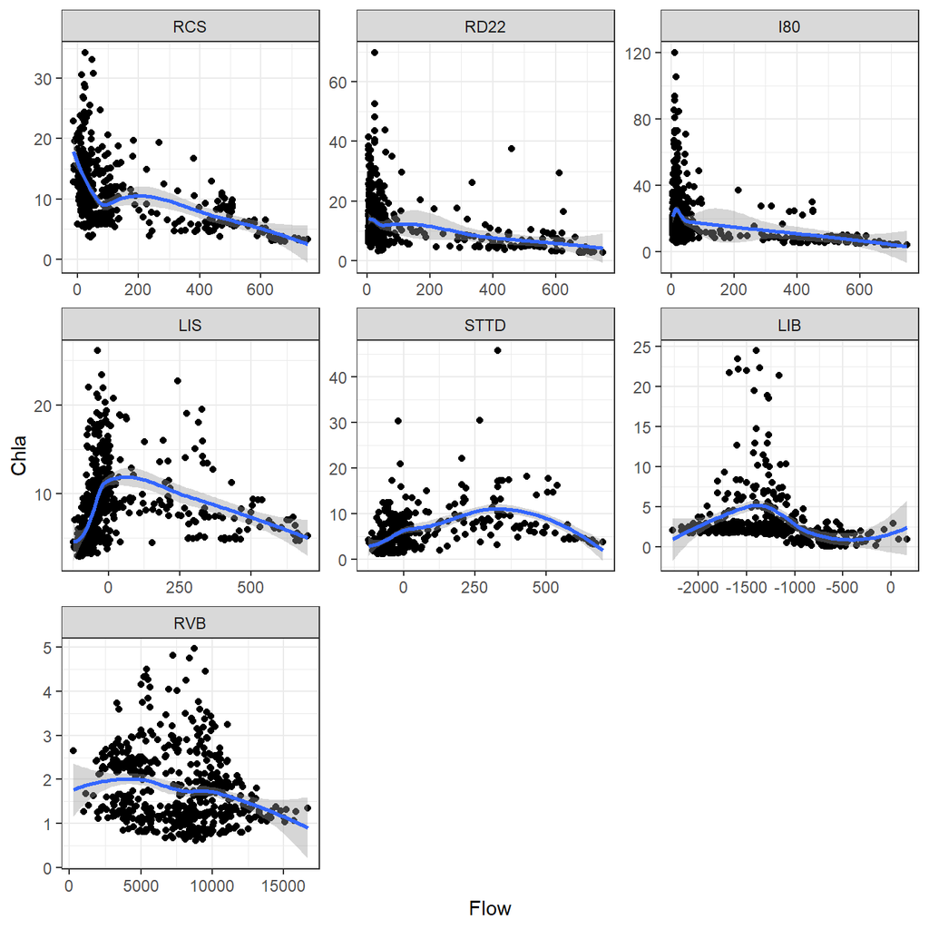

```r
df_chla_c2 %>%
  ggplot(aes(x = Flow, y = Chla)) +
  geom_point() +
  geom_smooth(formula = "y ~ x") +
  facet_wrap(vars(StationCode), scales = "free") +
  theme_bw()
```

Let’s break these scatterplots apart by year to see how these patterns vary annually.

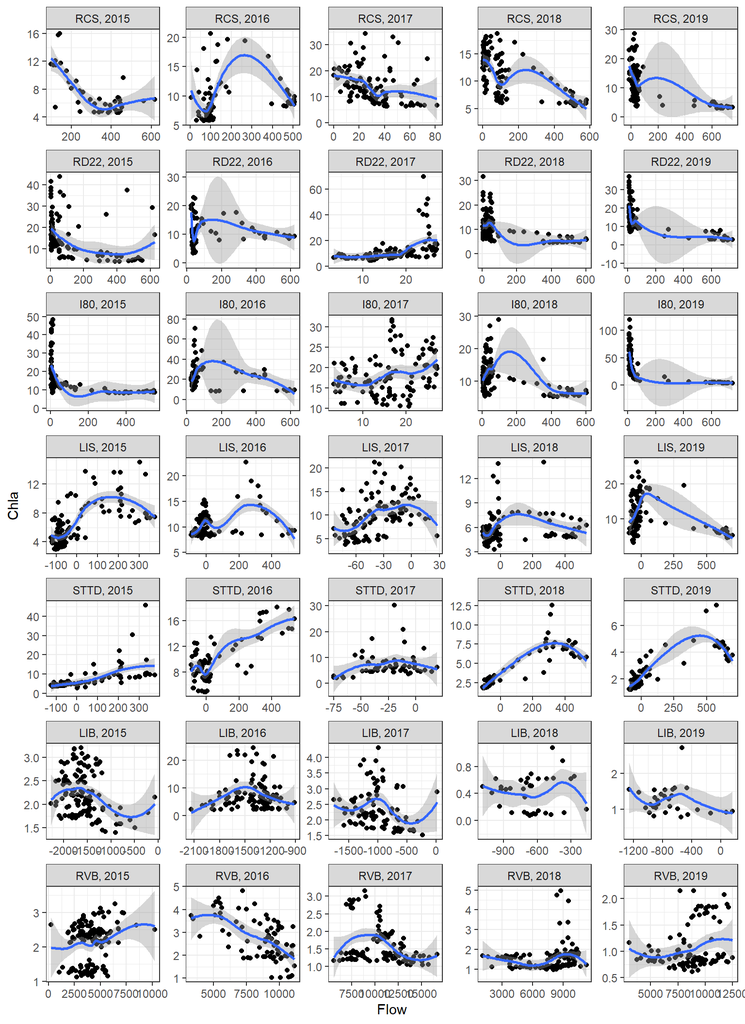

```r
df_chla_c2 %>%
  ggplot(aes(x = Flow, y = Chla)) +
  geom_point() +
  geom_smooth(formula = "y ~ x") +
  facet_wrap(
    vars(StationCode, Year),
    ncol = 5,
    scales = "free",
    labeller = labeller(.multi_line = FALSE)
  ) +
  theme_bw()
```

The patterns appear to vary annually at each station, which may justify using a 3-way interaction. We’ll stick with the model using 2-way interactions for now.

# GAM Model

We’ll try running a GAM including all two-way interactions between Year, Daily Average Flow, and Station, and a smooth term for day of year to account for seasonality. First we’ll run the GAM without accounting for serial autocorrelation.

## Initial Model

```r
m_chla_gam <- gam(
  Chla_log ~ (Year_fct + Flow + StationCode)^2 + s(DOY),
  data = df_chla_c2,
  method = "REML"
)
```

Lets look at the model summary and diagnostics:

```r
summary(m_chla_gam)
```

```
##
## Family: gaussian
## Link function: identity
##
## Formula:
## Chla_log ~ (Year_fct + Flow + StationCode)^2 + s(DOY)
##
## Parametric coefficients:
##                                Estimate Std. Error t value Pr(>|t|)
## (Intercept)                   9.324e+00  6.779e-02 137.533  < 2e-16 ***
## Year_fct2016                 -6.647e-02  7.620e-02  -0.872 0.383050
## Year_fct2017                  1.814e-01  7.624e-02   2.379 0.017421 *
## Year_fct2018                  1.138e-01  7.093e-02   1.605 0.108602
## Year_fct2019                  1.412e-02  7.115e-02   0.198 0.842685
## Flow                         -1.291e-03  1.073e-04 -12.027  < 2e-16 ***
## StationCodeRD22               3.354e-01  7.802e-02   4.299 1.76e-05 ***
## StationCodeI80                5.573e-01  7.982e-02   6.982 3.48e-12 ***
## StationCodeLIS               -6.824e-01  7.581e-02  -9.001  < 2e-16 ***
## StationCodeSTTD              -6.435e-01  7.722e-02  -8.333  < 2e-16 ***
## StationCodeLIB               -1.642e+00  1.259e-01 -13.039  < 2e-16 ***
## StationCodeRVB               -1.906e+00  1.135e-01 -16.793  < 2e-16 ***
## Year_fct2016:Flow            -8.297e-05  3.160e-05  -2.626 0.008676 **
## Year_fct2017:Flow            -6.890e-05  2.628e-05  -2.622 0.008774 **
## Year_fct2018:Flow            -2.473e-05  2.635e-05  -0.939 0.348020
## Year_fct2019:Flow            -5.359e-05  2.798e-05  -1.915 0.055550 .
## Year_fct2016:StationCodeRD22 -4.284e-01  9.375e-02  -4.569 5.07e-06 ***
## Year_fct2017:StationCodeRD22 -5.689e-01  9.257e-02  -6.146 8.85e-10 ***
## Year_fct2018:StationCodeRD22 -4.252e-01  8.679e-02  -4.899 1.01e-06 ***
## Year_fct2019:StationCodeRD22 -1.772e-01  8.705e-02  -2.035 0.041885 *
## Year_fct2016:StationCodeI80   2.333e-01  9.528e-02   2.449 0.014383 *
## Year_fct2017:StationCodeI80  -2.334e-01  9.408e-02  -2.481 0.013158 *
## Year_fct2018:StationCodeI80  -4.824e-01  8.845e-02  -5.454 5.27e-08 ***
## Year_fct2019:StationCodeI80   5.194e-01  8.872e-02   5.854 5.25e-09 ***
## Year_fct2016:StationCodeLIS   5.165e-01  9.173e-02   5.630 1.94e-08 ***
## Year_fct2017:StationCodeLIS   3.048e-01  9.167e-02   3.326 0.000891 ***
## Year_fct2018:StationCodeLIS  -1.300e-01  8.621e-02  -1.508 0.131662
## Year_fct2019:StationCodeLIS   5.536e-01  8.760e-02   6.319 2.96e-10 ***
## Year_fct2016:StationCodeSTTD  3.062e-01  9.446e-02   3.242 0.001200 **
## Year_fct2017:StationCodeSTTD -1.385e-01  9.936e-02  -1.394 0.163332
## Year_fct2018:StationCodeSTTD -7.592e-01  9.075e-02  -8.365  < 2e-16 ***
```

[output cut: 11 more lines]

```
## Flow:StationCodeLIS           1.546e-03  1.390e-04  11.123  < 2e-16 ***
## Flow:StationCodeSTTD          3.215e-03  1.405e-04  22.874  < 2e-16 ***
## Flow:StationCodeLIB           1.290e-03  1.233e-04  10.465  < 2e-16 ***
## Flow:StationCodeRVB           1.342e-03  1.053e-04  12.749  < 2e-16 ***
## ---
## Signif. codes:  0 '***' 0.001 '**' 0.01 '*' 0.05 '.' 0.1 ' ' 1
##
## Approximate significance of smooth terms:
##          edf Ref.df     F p-value
## s(DOY) 5.862  7.021 46.91  <2e-16 ***
## ---
## Signif. codes:  0 '***' 0.001 '**' 0.01 '*' 0.05 '.' 0.1 ' ' 1
##
## R-sq.(adj) =  0.851   Deviance explained = 85.3%
## -REML = 1769.2  Scale est. = 0.14698   n = 3478
```

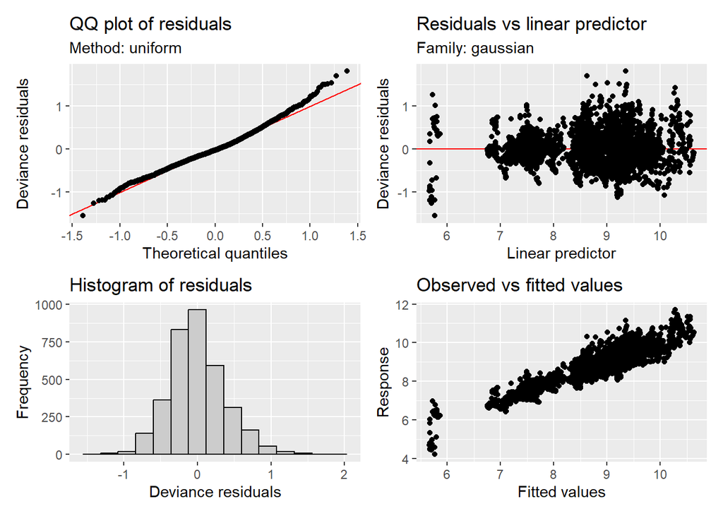

```r
appraise(m_chla_gam)
```

```r
k.check(m_chla_gam)
```

```
##        k'      edf   k-index p-value
## s(DOY)  9 5.862313 0.9253631       0
```

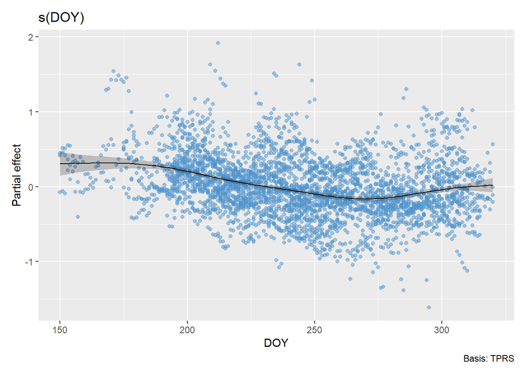

```r
draw(m_chla_gam, select = 1, residuals = TRUE, rug = FALSE)
```

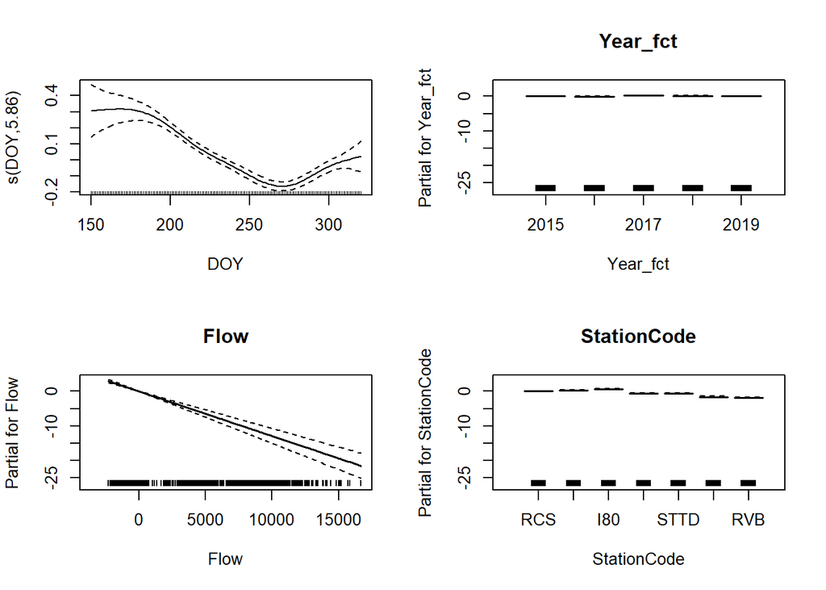

```r
plot(m_chla_gam, pages = 1, all.terms = TRUE)
```

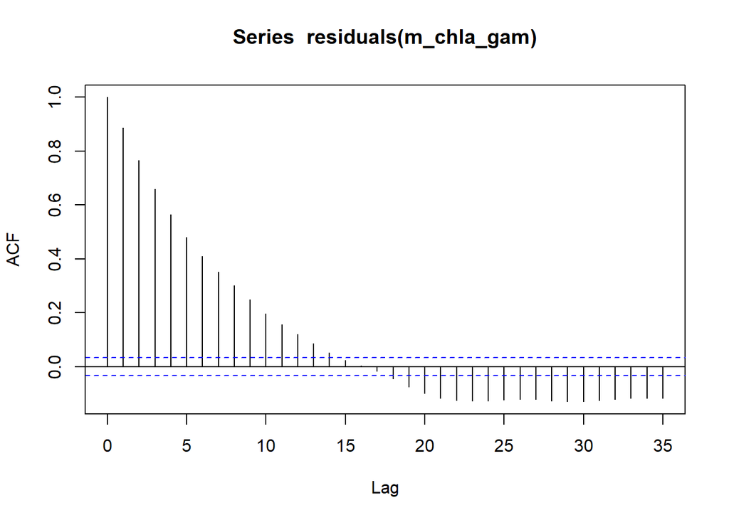

```r
acf(residuals(m_chla_gam))
```

```r
Box.test(residuals(m_chla_gam), lag = 20, type = 'Ljung-Box')
```

```
##
##  Box-Ljung test
##
## data:  residuals(m_chla_gam)
## X-squared = 10098, df = 20, p-value < 2.2e-16
```

## Model with k = 5

The model definitely has residual autocorrelation as indicated by the ACF plot and the Box-Ljung test. Even though the p-value for the k-check is zero, the smooth term for day of year appears to be overfitted. Let’s try a smaller k-value for the smooth first, then lets try to address the residual autocorrelation.

```r
m_chla_gam_k5 <- gam(
  Chla_log ~ (Year_fct + Flow + StationCode)^2 + s(DOY, k = 5),
  data = df_chla_c2,
  method = "REML"
)

summary(m_chla_gam_k5)
```

```
##
## Family: gaussian
## Link function: identity
##
## Formula:
## Chla_log ~ (Year_fct + Flow + StationCode)^2 + s(DOY, k = 5)
##
## Parametric coefficients:
##                                Estimate Std. Error t value Pr(>|t|)
## (Intercept)                   9.322e+00  6.781e-02 137.468  < 2e-16 ***
## Year_fct2016                 -6.414e-02  7.625e-02  -0.841 0.400279
## Year_fct2017                  1.818e-01  7.628e-02   2.383 0.017221 *
## Year_fct2018                  1.125e-01  7.096e-02   1.585 0.113065
## Year_fct2019                  1.372e-02  7.116e-02   0.193 0.847183
## Flow                         -1.275e-03  1.059e-04 -12.038  < 2e-16 ***
## StationCodeRD22               3.344e-01  7.804e-02   4.285 1.88e-05 ***
## StationCodeI80                5.559e-01  7.984e-02   6.963 3.98e-12 ***
## StationCodeLIS               -6.816e-01  7.585e-02  -8.987  < 2e-16 ***
## StationCodeSTTD              -6.447e-01  7.727e-02  -8.344  < 2e-16 ***
## StationCodeLIB               -1.640e+00  1.260e-01 -13.019  < 2e-16 ***
## StationCodeRVB               -1.908e+00  1.136e-01 -16.801  < 2e-16 ***
## Year_fct2016:Flow            -8.355e-05  3.159e-05  -2.645 0.008212 **
## Year_fct2017:Flow            -7.085e-05  2.628e-05  -2.696 0.007046 **
## Year_fct2018:Flow            -2.494e-05  2.636e-05  -0.946 0.344219
## Year_fct2019:Flow            -5.410e-05  2.800e-05  -1.932 0.053386 .
## Year_fct2016:StationCodeRD22 -4.235e-01  9.371e-02  -4.519 6.41e-06 ***
## Year_fct2017:StationCodeRD22 -5.668e-01  9.263e-02  -6.119 1.05e-09 ***
## Year_fct2018:StationCodeRD22 -4.231e-01  8.681e-02  -4.874 1.14e-06 ***
## Year_fct2019:StationCodeRD22 -1.754e-01  8.709e-02  -2.014 0.044067 *
## Year_fct2016:StationCodeI80   2.386e-01  9.525e-02   2.505 0.012300 *
## Year_fct2017:StationCodeI80  -2.309e-01  9.413e-02  -2.453 0.014198 *
## Year_fct2018:StationCodeI80  -4.800e-01  8.848e-02  -5.425 6.21e-08 ***
## Year_fct2019:StationCodeI80   5.216e-01  8.876e-02   5.876 4.60e-09 ***
## Year_fct2016:StationCodeLIS   5.173e-01  9.177e-02   5.637 1.87e-08 ***
## Year_fct2017:StationCodeLIS   3.056e-01  9.172e-02   3.332 0.000870 ***
## Year_fct2018:StationCodeLIS  -1.288e-01  8.627e-02  -1.493 0.135495
## Year_fct2019:StationCodeLIS   5.536e-01  8.765e-02   6.316 3.02e-10 ***
## Year_fct2016:StationCodeSTTD  3.119e-01  9.445e-02   3.302 0.000971 ***
## Year_fct2017:StationCodeSTTD -1.372e-01  9.943e-02  -1.380 0.167655
## Year_fct2018:StationCodeSTTD -7.586e-01  9.080e-02  -8.354  < 2e-16 ***
```

[output cut: 11 more lines]

```
## Flow:StationCodeLIS           1.541e-03  1.391e-04  11.079  < 2e-16 ***
## Flow:StationCodeSTTD          3.211e-03  1.406e-04  22.832  < 2e-16 ***
## Flow:StationCodeLIB           1.275e-03  1.220e-04  10.452  < 2e-16 ***
## Flow:StationCodeRVB           1.327e-03  1.039e-04  12.773  < 2e-16 ***
## ---
## Signif. codes:  0 '***' 0.001 '**' 0.01 '*' 0.05 '.' 0.1 ' ' 1
##
## Approximate significance of smooth terms:
##          edf Ref.df     F p-value
## s(DOY) 3.757  3.966 81.39  <2e-16 ***
## ---
## Signif. codes:  0 '***' 0.001 '**' 0.01 '*' 0.05 '.' 0.1 ' ' 1
##
## R-sq.(adj) =  0.851   Deviance explained = 85.3%
## -REML = 1770.4  Scale est. = 0.14725   n = 3478
```

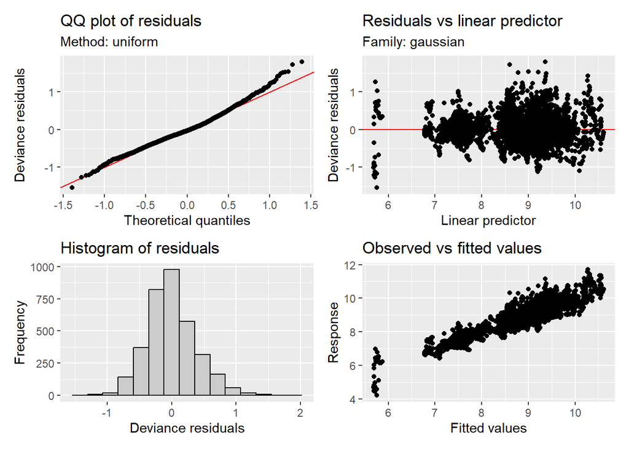

```r
appraise(m_chla_gam_k5)
```

```r
k.check(m_chla_gam_k5)
```

```
##        k'      edf   k-index p-value
## s(DOY)  4 3.756521 0.9228792       0
```

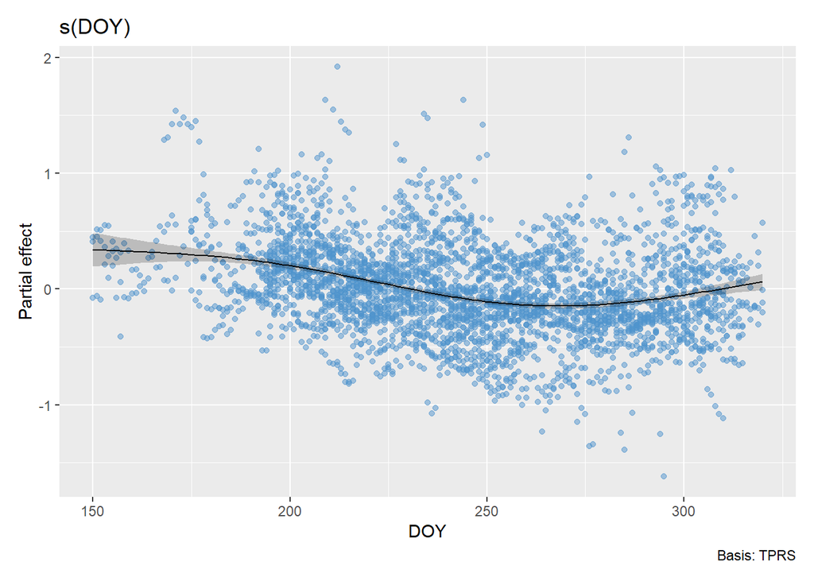

```r
draw(m_chla_gam_k5, select = 1, residuals = TRUE, rug = FALSE)
```

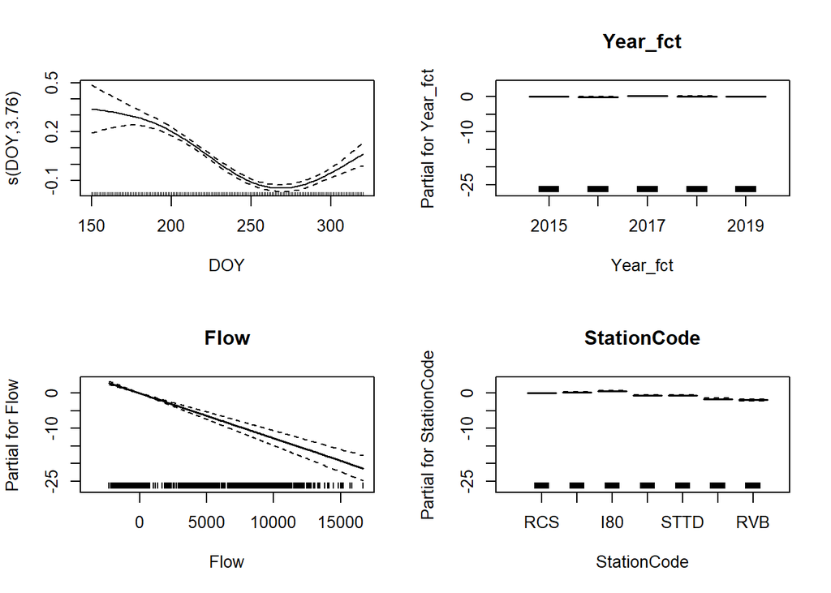

```r
plot(m_chla_gam_k5, pages = 1, all.terms = TRUE)
```

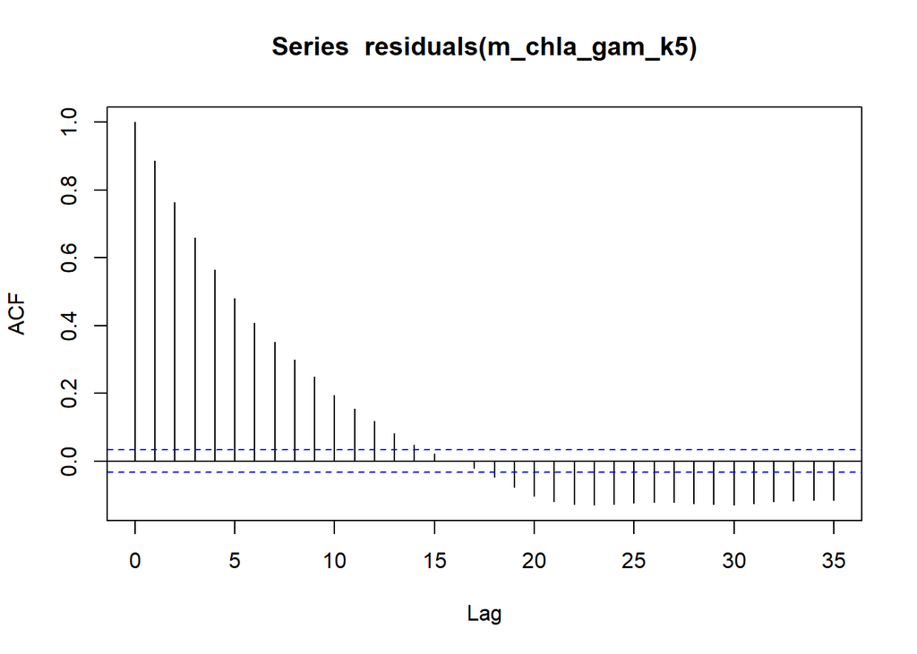

```r
acf(residuals(m_chla_gam_k5))
```

```r
Box.test(residuals(m_chla_gam_k5), lag = 20, type = 'Ljung-Box')
```

```
##
##  Box-Ljung test
##
## data:  residuals(m_chla_gam_k5)
## X-squared = 10096, df = 20, p-value < 2.2e-16
```

Changing the k-value to 5 seems to help reduce the “wiggliness” of the smooth term for DOY, but the p-value for the k-check is still zero. Despite this, lets proceed with a k-value of 5.

## Model with AR() correlation structure

Now, we’ll try to deal with the residual autocorrelation. We’ll run AR(1), AR(3), and AR(4) models and compare them using AIC. It wasn’t possible running an AR(2) model.

```r
# Define model formula as an object
f_chla_gam_k5 <- as.formula("Chla_log ~ (Year_fct + Flow + StationCode)^2 + s(DOY, k = 5)")

# Fit original model with k = 5 and three successive AR(p) models
m_chla_gamm_k5 <- gamm(
  f_chla_gam_k5,
  data = df_chla_c2,
  method = "REML"
)

m_chla_gamm_k5_ar1 <- gamm(
  f_chla_gam_k5,
  data = df_chla_c2,
  correlation = corARMA(form = ~ 1|Year_fct/StationCode, p = 1), # grouped by Year_fct and StationCode
  method = "REML"
)

m_chla_gamm_k5_ar3 <- gamm(
  f_chla_gam_k5,
  data = df_chla_c2,
  correlation = corARMA(form = ~ 1|Year_fct/StationCode, p = 3),
  method = "REML"
)

m_chla_gamm_k5_ar4 <- gamm(
  f_chla_gam_k5,
  data = df_chla_c2,
  correlation = corARMA(form = ~ 1|Year_fct/StationCode, p = 4),
  method = "REML"
)

# Compare models
anova(
  m_chla_gamm_k5$lme,
  m_chla_gamm_k5_ar1$lme,
  m_chla_gamm_k5_ar3$lme,
  m_chla_gamm_k5_ar4$lme
)
```

```
##                        Model df       AIC       BIC    logLik   Test  L.Ratio
## m_chla_gamm_k5$lme         1 49  3638.827  3939.716 -1770.413
## m_chla_gamm_k5_ar1$lme     2 50 -2092.217 -1785.187  1096.109 1 vs 2 5733.044
## m_chla_gamm_k5_ar3$lme     3 52 -2110.010 -1790.698  1107.005 2 vs 3   21.793
## m_chla_gamm_k5_ar4$lme     4 53 -2108.176 -1782.724  1107.088 3 vs 4    0.166
##                        p-value
## m_chla_gamm_k5$lme
## m_chla_gamm_k5_ar1$lme  <.0001
## m_chla_gamm_k5_ar3$lme  <.0001
## m_chla_gamm_k5_ar4$lme  0.6833
```

It looks like the AR(3) model has the best fit according to the AIC values and backed up by the BIC values. Let’s take a closer look at that one.

## AR(3) Model

```r
# Pull out the residuals and the GAM model
resid_ar3 <- residuals(m_chla_gamm_k5_ar3$lme, type = "normalized")
m_chla_gamm_k5_ar3_gam <- m_chla_gamm_k5_ar3$gam

summary(m_chla_gamm_k5_ar3_gam)
```

```
##
## Family: gaussian
## Link function: identity
##
## Formula:
## Chla_log ~ (Year_fct + Flow + StationCode)^2 + s(DOY, k = 5)
##
## Parametric coefficients:
##                                Estimate Std. Error t value Pr(>|t|)
## (Intercept)                   9.182e+00  2.976e-01  30.856  < 2e-16 ***
## Year_fct2016                 -3.290e-02  3.837e-01  -0.086 0.931666
## Year_fct2017                  3.300e-01  3.660e-01   0.902 0.367266
## Year_fct2018                  1.276e-01  3.567e-01   0.358 0.720649
## Year_fct2019                  8.750e-02  3.577e-01   0.245 0.806782
## Flow                         -1.789e-04  1.771e-04  -1.010 0.312618
## StationCodeRD22               3.127e-01  3.642e-01   0.858 0.390722
## StationCodeI80                7.079e-01  3.745e-01   1.890 0.058790 .
## StationCodeLIS               -5.890e-01  3.567e-01  -1.651 0.098781 .
## StationCodeSTTD              -4.821e-01  3.649e-01  -1.321 0.186468
## StationCodeLIB               -1.233e+00  3.639e-01  -3.387 0.000714 ***
## StationCodeRVB               -1.521e+00  3.589e-01  -4.239 2.31e-05 ***
## Year_fct2016:Flow            -5.766e-06  1.928e-05  -0.299 0.764890
## Year_fct2017:Flow            -4.860e-06  1.971e-05  -0.247 0.805276
## Year_fct2018:Flow            -3.764e-06  2.113e-05  -0.178 0.858612
## Year_fct2019:Flow            -2.466e-05  1.970e-05  -1.252 0.210563
## Year_fct2016:StationCodeRD22 -4.413e-01  4.927e-01  -0.896 0.370425
## Year_fct2017:StationCodeRD22 -5.871e-01  4.691e-01  -1.252 0.210739
## Year_fct2018:StationCodeRD22 -4.223e-01  4.584e-01  -0.921 0.356958
## Year_fct2019:StationCodeRD22 -1.647e-01  4.602e-01  -0.358 0.720454
## Year_fct2016:StationCodeI80   1.268e-01  5.001e-01   0.254 0.799813
## Year_fct2017:StationCodeI80  -3.773e-01  4.769e-01  -0.791 0.428985
## Year_fct2018:StationCodeI80  -6.230e-01  4.664e-01  -1.336 0.181707
## Year_fct2019:StationCodeI80   3.945e-01  4.682e-01   0.843 0.399515
## Year_fct2016:StationCodeLIS   6.941e-01  4.801e-01   1.446 0.148346
## Year_fct2017:StationCodeLIS   1.689e-01  4.665e-01   0.362 0.717318
## Year_fct2018:StationCodeLIS  -1.553e-01  4.543e-01  -0.342 0.732445
## Year_fct2019:StationCodeLIS   4.100e-01  4.594e-01   0.892 0.372284
## Year_fct2016:StationCodeSTTD  3.473e-01  4.953e-01   0.701 0.483162
## Year_fct2017:StationCodeSTTD -5.769e-01  5.017e-01  -1.150 0.250250
## Year_fct2018:StationCodeSTTD -8.716e-01  4.761e-01  -1.831 0.067211 .
```

[output cut: 11 more lines]

```
## Flow:StationCodeLIS          -3.154e-05  2.857e-04  -0.110 0.912094
## Flow:StationCodeSTTD          1.424e-03  2.900e-04   4.909 9.56e-07 ***
## Flow:StationCodeLIB           3.538e-04  1.820e-04   1.944 0.051964 .
## Flow:StationCodeRVB           1.792e-04  1.770e-04   1.012 0.311485
## ---
## Signif. codes:  0 '***' 0.001 '**' 0.01 '*' 0.05 '.' 0.1 ' ' 1
##
## Approximate significance of smooth terms:
##          edf Ref.df     F p-value
## s(DOY) 3.678  3.678 11.22  <2e-16 ***
## ---
## Signif. codes:  0 '***' 0.001 '**' 0.01 '*' 0.05 '.' 0.1 ' ' 1
##
## R-sq.(adj) =  0.818
##   Scale est. = 0.22629   n = 3478
```

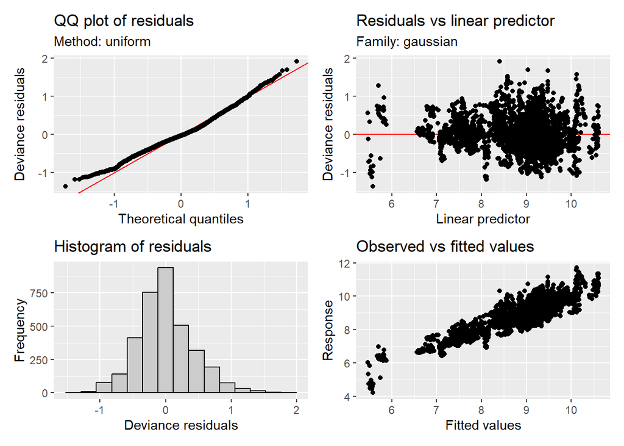

```r
appraise(m_chla_gamm_k5_ar3_gam)
```

```r
k.check(m_chla_gamm_k5_ar3_gam)
```

```
##        k'     edf  k-index p-value
## s(DOY)  4 3.67766 0.801434       0
```

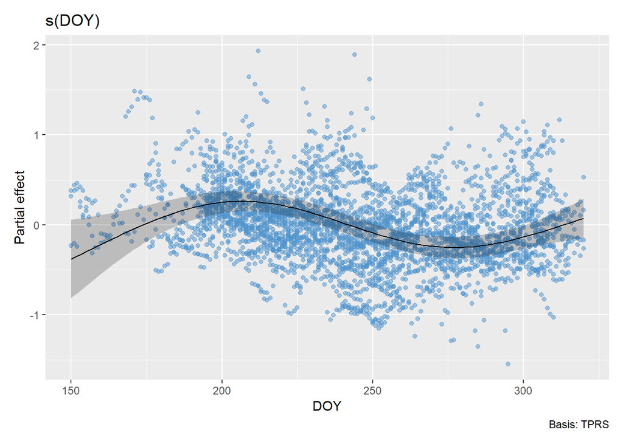

```r
draw(m_chla_gamm_k5_ar3_gam, select = 1, residuals = TRUE, rug = FALSE)
```

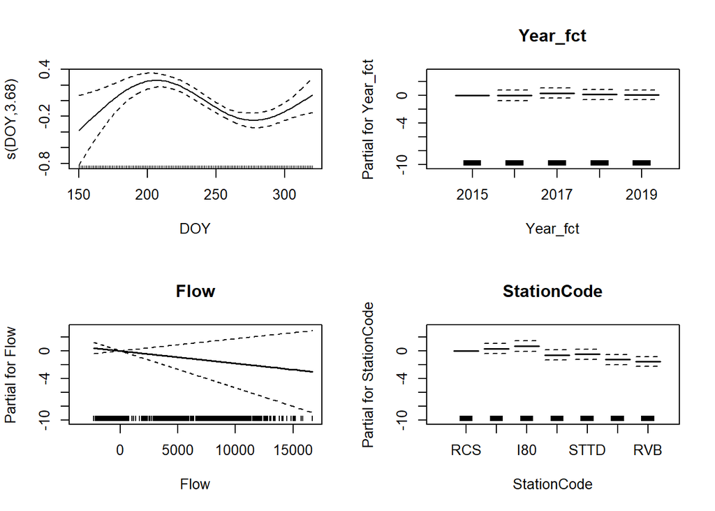

```r
plot(m_chla_gamm_k5_ar3_gam, pages = 1, all.terms = TRUE)
```

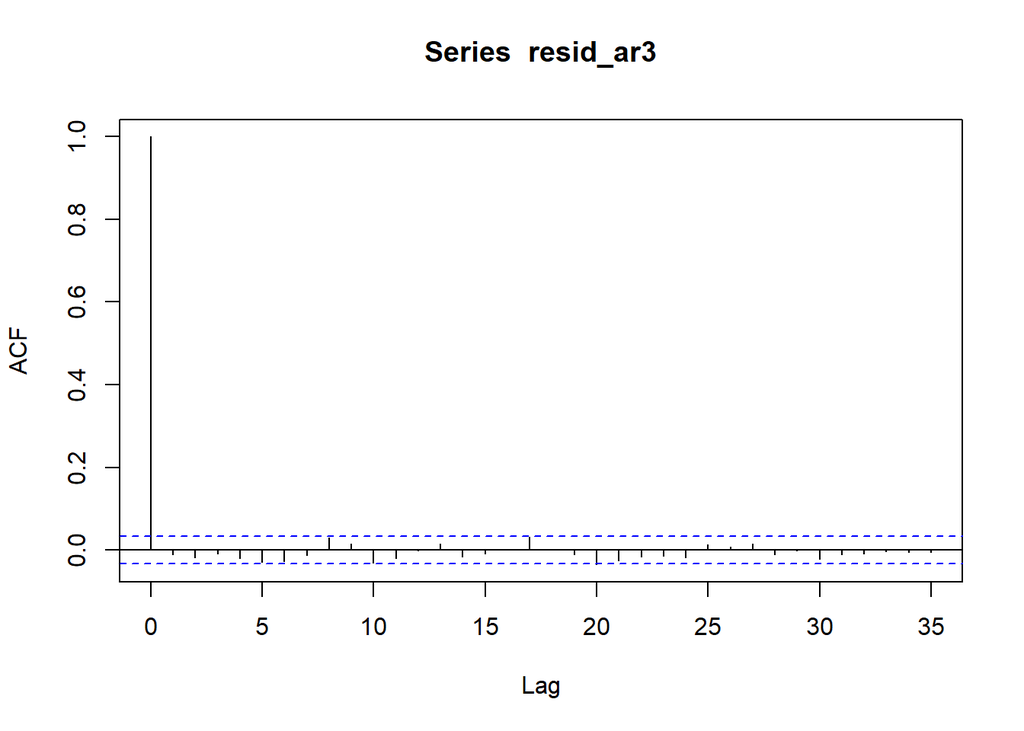

```r
acf(resid_ar3)
```

```r
Box.test(resid_ar3, lag = 20, type = 'Ljung-Box')
```

```
##
##  Box-Ljung test
##
## data:  resid_ar3
## X-squared = 28.268, df = 20, p-value = 0.1032
```

The AR(3) model has much less residual autocorrelation, and the diagnostics plots look pretty good. What does the ANOVA table look like?

### ANOVA table

```r
# the anova.gam function is similar to a type 3 ANOVA
anova(m_chla_gamm_k5_ar3_gam)
```

```
##
## Family: gaussian
## Link function: identity
##
## Formula:
## Chla_log ~ (Year_fct + Flow + StationCode)^2 + s(DOY, k = 5)
##
## Parametric Terms:
##                      df      F  p-value
## Year_fct              4  0.383    0.821
## Flow                  1  1.020    0.313
## StationCode           6 14.298 3.67e-16
## Year_fct:Flow         4  0.411    0.801
## Year_fct:StationCode 24  3.779 1.56e-09
## Flow:StationCode      6 16.694  < 2e-16
##
## Approximate significance of smooth terms:
##          edf Ref.df     F p-value
## s(DOY) 3.678  3.678 11.22  <2e-16
```

The main effect of StationCode and the Year:StationCode and Flow:StationCode interactions were significant among the parametric terms of the model. Let’s visualize the effect of flow on chlorophyll concentrations for each station.

### Effect of flow for each station

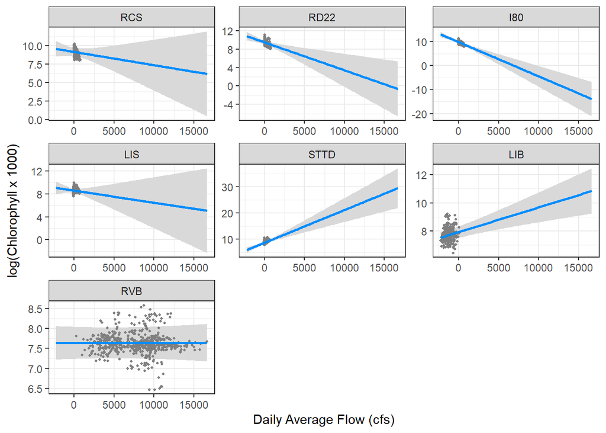

```r
# Add the data back to the gam object so it works with visreg
m_chla_gamm_k5_ar3_gam$data <- df_chla_c2

# Visualize the effect of flow on chlorophyll concentrations for each station
  # according to the model
# First facetted by station
visreg(m_chla_gamm_k5_ar3_gam, xvar = "Flow", by = "StationCode", gg = TRUE) +
  facet_wrap(vars(StationCode), scales = "free") +
  theme_bw() +
  ylab("log(Chlorophyll x 1000)") +
  xlab("Daily Average Flow (cfs)")
```

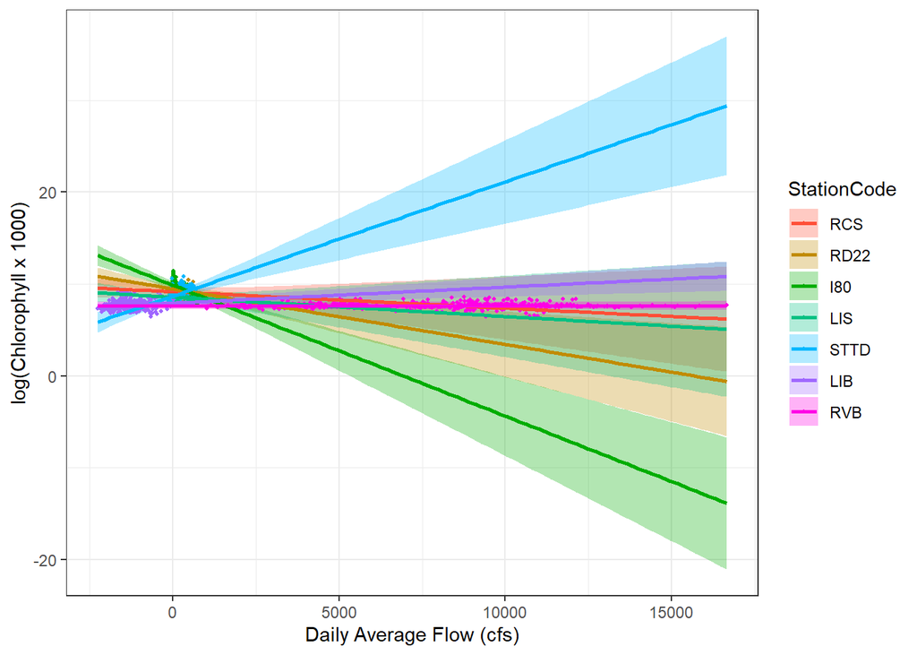

```r
# All stations overlayed
visreg(m_chla_gamm_k5_ar3_gam, xvar = "Flow", by = "StationCode", overlay = TRUE, gg = TRUE) +
  theme_bw() +
  ylab("log(Chlorophyll x 1000)") +
  xlab("Daily Average Flow (cfs)")
```

It looks like the slopes for the chlorophyll vs flow relationships are significantly different than zero for RD22, I-80, and STTD. RD22 and I-80 both have negative slopes while STTD has a positive slope. It’s difficult to really see this though due to the x-axis scale on these plots and the significant Flow:StationCode interaction, so it may be interesting to run separate models for each of these stations. In addition, I’m somewhat unsure what results `visreg` is showing in these plots. These are conditional plots but they may be displaying only a subset of the model results.

### Pairwise contrasts

The Year:StationCode interaction was also significant, so let’s take a closer look at its pairwise contrasts.

```r
# Contrasts in Station main effect
emmeans(
  m_chla_gamm_k5_ar3,
  data = df_chla_c2,
  specs = pairwise ~ StationCode
)
```

```
## $emmeans
##  StationCode emmean    SE   df lower.CL upper.CL
##  RCS           9.03 0.210 3428     8.62     9.44
##  RD22          8.53 0.217 3428     8.10     8.95
##  I80           8.20 0.254 3428     7.70     8.70
##  LIS           8.63 0.272 3428     8.09     9.16
##  STTD          9.74 0.280 3428     9.19    10.29
##  LIB           7.69 0.154 3428     7.39     7.99
##  RVB           7.45 0.115 3428     7.22     7.67
##
## Results are averaged over the levels of: Year_fct
## Confidence level used: 0.95
##
## $contrasts
##  contrast    estimate    SE   df t.ratio p.value
##  RCS - RD22     0.504 0.299 3428   1.683  0.6277
##  RCS - I80      0.832 0.328 3428   2.536  0.1468
##  RCS - LIS      0.402 0.342 3428   1.175  0.9037
##  RCS - STTD    -0.707 0.349 3428  -2.029  0.3963
##  RCS - LIB      1.341 0.256 3428   5.227  <.0001
##  RCS - RVB      1.581 0.235 3428   6.720  <.0001
##  RD22 - I80     0.328 0.333 3428   0.986  0.9572
##  RD22 - LIS    -0.102 0.347 3428  -0.294  0.9999
##  RD22 - STTD   -1.211 0.353 3428  -3.430  0.0109
##  RD22 - LIB     0.837 0.262 3428   3.190  0.0242
##  RD22 - RVB     1.077 0.241 3428   4.464  0.0002
##  I80 - LIS     -0.430 0.371 3428  -1.157  0.9099
##  I80 - STTD    -1.539 0.377 3428  -4.078  0.0009
##  I80 - LIB      0.509 0.295 3428   1.726  0.5986
##  I80 - RVB      0.749 0.276 3428   2.715  0.0947
##  LIS - STTD    -1.109 0.390 3428  -2.847  0.0669
##  LIS - LIB      0.939 0.310 3428   3.024  0.0403
##  LIS - RVB      1.179 0.292 3428   4.032  0.0011
##  STTD - LIB     2.048 0.318 3428   6.444  <.0001
##  STTD - RVB     2.288 0.301 3428   7.613  <.0001
##  LIB - RVB      0.240 0.184 3428   1.308  0.8486
##
## Results are averaged over the levels of: Year_fct
## P value adjustment: tukey method for comparing a family of 7 estimates
```

```r
# Contrasts in Station for each Year
multcomp::cld(
  emmeans(
    m_chla_gamm_k5_ar3,
    data = df_chla_c2,
    specs = pairwise ~ StationCode | Year_fct
  )$emmeans,
  sort = FALSE,
  Letters = letters
)
```

```
## Year_fct = 2015:
##  StationCode emmean    SE   df lower.CL upper.CL .group
##  RCS           8.94 0.335 3428     8.28     9.59  ab
##  RD22          8.76 0.283 3428     8.20     9.31  a
##  I80           8.20 0.324 3428     7.57     8.84  a c
##  LIS           8.31 0.327 3428     7.67     8.95  a c
##  STTD         10.10 0.339 3428     9.44    10.77   b
##  LIB           8.11 0.233 3428     7.66     8.57  a c
##  RVB           7.62 0.201 3428     7.23     8.02    c
##
## Year_fct = 2016:
##  StationCode emmean    SE   df lower.CL upper.CL .group
##  RCS           8.90 0.304 3428     8.30     9.49  ab
##  RD22          8.27 0.301 3428     7.68     8.87  ab
##  I80           8.29 0.328 3428     7.65     8.93  ab
##  LIS           8.97 0.334 3428     8.31     9.62  ab
##  STTD         10.41 0.347 3428     9.73    11.09    c
##  LIB           9.02 0.250 3428     8.53     9.51  a
##  RVB           7.92 0.274 3428     7.38     8.46   b
##
## Year_fct = 2017:
##  StationCode emmean    SE   df lower.CL upper.CL .group
##  RCS           9.26 0.294 3428     8.68     9.84  ab
##  RD22          8.49 0.295 3428     7.91     9.07  abcd
##  I80           8.15 0.326 3428     7.51     8.79  a cd
##  LIS           8.80 0.343 3428     8.13     9.48  abc
##  STTD          9.85 0.384 3428     9.10    10.60   b
##  LIB           8.05 0.242 3428     7.57     8.52    cd
##  RVB           7.40 0.255 3428     6.90     7.90     d
##
## Year_fct = 2018:
##  StationCode emmean    SE   df lower.CL upper.CL .group
##  RCS           9.06 0.272 3428     8.53     9.59  a
##  RD22          8.46 0.279 3428     7.91     9.00  ab
##  I80           7.70 0.308 3428     7.10     8.30   bc
##  LIS           8.28 0.327 3428     7.64     8.92  abc
##  STTD          9.35 0.348 3428     8.67    10.04  a
##  LIB           6.04 0.322 3428     5.40     6.67     d
##  RVB           7.30 0.232 3428     6.84     7.75    c
##
## Year_fct = 2019:
##  StationCode emmean    SE   df lower.CL upper.CL .group
##  RCS           9.00 0.273 3428     8.46     9.53  a
##  RD22          8.65 0.278 3428     8.11     9.19  a
##  I80           8.65 0.305 3428     8.06     9.25  a
##  LIS           8.78 0.321 3428     8.15     9.41  a
##  STTD          8.97 0.329 3428     8.32     9.61  a
##  LIB           7.24 0.339 3428     6.57     7.90   b
##  RVB           7.01 0.246 3428     6.52     7.49   b
##
## Confidence level used: 0.95
## P value adjustment: tukey method for comparing a family of 7 estimates
## significance level used: alpha = 0.05
## NOTE: If two or more means share the same grouping symbol,
##       then we cannot show them to be different.
##       But we also did not show them to be the same.
```

# Conclusion

These results seem mixed to me. It looks like daily average flow has an effect on chlorophyll concentrations at some of the stations, but flow doesn’t seem to be a good predictor overall. It may be interesting to run separate models for a few of the stations - RD22, I-80, and STTD - that appeared to have slopes that were significantly different than zero.